# Robust Algorithm Evaluation for FinTech Decision-Making

Upgraded from SCEM coursework (Task I) to an industry-oriented project

Mingyu Wang

## Portfolio note

This file is an upgraded version of my original coursework submission. Assessment-only instructions were removed and the narrative was rewritten to reflect an industry-oriented mindset (robustness, decision relevance, and explicit assumptions). Core computations are preserved for reproducibility.

## Executive summary

This project evaluates multiple configurations of a Differential Evolution (DE) optimiser under two settings: (1) a single benchmark problem (pilot), and (2) a multi-problem blocked design (robustness check).

Key outcome: the single-problem pilot selects one configuration as best, but the blocked multi-problem experiment changes the recommendation, illustrating why **robust strategy selection** matters in FinTech decision-making where conditions shift across regimes.

## Upgrade log (from coursework → portfolio)

- Renamed metadata to remove course-specific identifiers.
- Rewrote explanations to emphasise decision-making under uncertainty (FinTech context).
- Optimised data-generation code (preallocation) and added integrity checks.
- Corrected the blocked analysis to use **problem-level cell means** (RCBD) to avoid pseudo-replication.
- Expanded the independence discussion (design-driven), not just a bullet list.

## Pilot Study: Single-Problem Evaluation

### Hypotheses and evaluation objective

**Null hypothesis (H₀).**  
All Differential Evolution (DE) configurations have the same population mean log-loss  
($\mu_1 = \cdots = \mu_K$) on the target problem.

**Alternative hypothesis (H₁).**  
At least one configuration differs in population mean log-loss.

To assess whether configuration choice materially affects expected performance, I apply a one-way ANOVA omnibus test. Each observation is generated from an independent algorithm run under a controlled evaluation protocol (fixed RNG seed, identical evaluation budgets across configurations). Under this design, observed performance differences can be attributed to configuration effects rather than experimental artefacts.

### Experimental design and data generation

```r
set.seed(CW_SEED) ## <--- DO NOT CHANGE THIS LINE

# Generate nruns observations per method (preallocated for speed/reproducibility)
nruns <- exp_pars$nruns
M <- length(method.names)
N <- nruns * M

Method <- rep(method.names, each = nruns)
Value  <- numeric(N)

idx <- 0L
for (mn in method.names) {
  vals <- replicate(nruns, log(ExpDE2(method.name = mn, problem.name = my.problem)))
  rng <- (idx + 1L):(idx + nruns)
  Value[rng] <- vals
  idx <- idx + nruns
}

myres <- data.frame(
  Method = factor(Method, levels = method.names),
  Config = factor(method_label[Method], levels = method_map$Config),
  Value  = Value
)

stopifnot(nrow(myres) == N)
head(myres)
```

```
##         Method   Config    Value
## 1 DE.2708591.A Config A 2.536783
## 2 DE.2708591.A Config A 2.675532
## 3 DE.2708591.A Config A 2.793391
## 4 DE.2708591.A Config A 2.857790
## 5 DE.2708591.A Config A 2.539899
## 6 DE.2708591.A Config A 2.821157
```

```r
dim(myres)
```

```
## [1] 250   3
```

```r
## myres has (nruns x number of methods) rows as required.
```

### Estimation and confidence intervals

```r
myCIs01 <- myres |>
  dplyr::group_by(Method) |>
  dplyr::summarise(
    n    = dplyr::n(),
    Mean = mean(Value),
    sd   = stats::sd(Value),
    se   = sd / sqrt(n),
    tcrit = stats::qt(1 - exp_pars$alpha/2, df = n - 1),
    CI.lower = Mean - tcrit * se,
    CI.upper = Mean + tcrit * se,
    .groups = "drop"
  ) |>
  dplyr::mutate(Config = method_label[as.character(Method)]) |>
  dplyr::select(Config, Method, Mean, CI.lower, CI.upper)

myCIs01
```

```
## # A tibble: 5 × 5
##   Config   Method        Mean CI.lower CI.upper
##   <chr>    <fct>        <dbl>    <dbl>    <dbl>
## 1 Config A DE.2708591.A  2.75     2.72     2.78
## 2 Config B DE.2708591.B  3.04     3.01     3.06
## 3 Config C DE.2708591.C  2.12     2.09     2.16
## 4 Config D DE.2708591.D  2.34     2.30     2.37
## 5 Config E DE.2708591.E  2.91     2.87     2.94
```

```r
utils::write.csv(myCIs01, file = file.path('results','summary_single_problem_cis.csv'), row.names = FALSE)
```

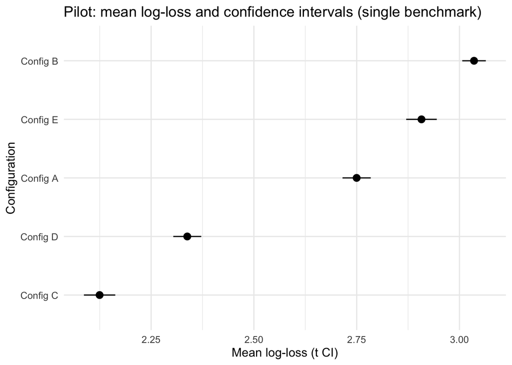

```r
p_ci <- ggplot2::ggplot(
  myCIs01,
  ggplot2::aes(y = reorder(Config, Mean), x = Mean, xmin = CI.lower, xmax = CI.upper)
) +
  ggplot2::geom_pointrange() +
  ggplot2::labs(
    y = "Configuration",
    x = "Mean log-loss (t CI)",
    title = "Pilot: mean log-loss and confidence intervals (single benchmark)"
  ) +
  ggplot2::theme_minimal(base_size = 12)

p_ci
```

```r
ggplot2::ggsave(filename = file.path("figures","ci_single_problem.png"), width = 7, height = 3.8, dpi = 160)
```

### Omnibus statistical test

```r
# ANOVA

mytest01 <- aov(Value ~ Method, data = myres)

summary(mytest01)
```

```
##              Df Sum Sq Mean Sq F value Pr(>F)
## Method        4 29.828   7.457   620.7 <2e-16 ***
## Residuals   245  2.943   0.012
## ---
## Signif. codes:  0 '***' 0.001 '**' 0.01 '*' 0.05 '.' 0.1 ' ' 1
```

```r
## (DON'T FORGET THAT THE OBJECT RETURNED BY THE STATISTICAL TEST FUNCTION
## SHOULD BE STORED IN A VARIABLE CALLED mytest01).
```

The one-way ANOVA indicates statistically significant differences in mean log-loss across configurations. The p-value is far below the predefined significance level (α = 0.03), so I reject the null hypothesis of equal means. This implies at least one configuration performs differently on the pilot benchmark.

### Model assumptions and diagnostics

Assumptions and diagnostics. The ANOVA relies on (i) independent observations (separate algorithm runs under a fixed evaluation protocol), (ii) approximately normal residuals (helped by the log transform; checked with a QQ plot), and (iii) roughly constant variance across groups (checked via residual vs fitted and scale-location plots). The diagnostic plots below are used as sanity checks rather than proofs.

```r
# Save diagnostics to figures/
grDevices::png(filename = file.path("figures", "anova_diagnostics_single_problem.png"),
               width = 1100, height = 800, res = 160)
par(mfrow = c(2, 2))
plot(mytest01, las = 1, pch = 20)
dev.off()
```

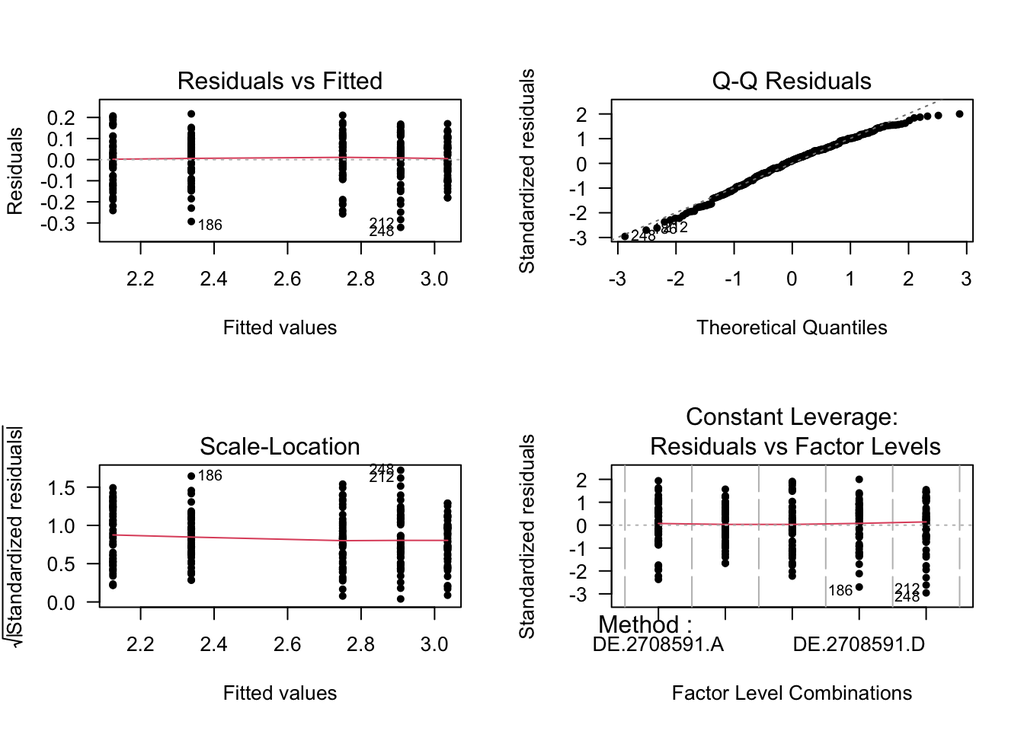

```r
# Also show in the knitted report
par(mfrow = c(2, 2))
plot(mytest01, las = 1, pch = 20)
```

```r
par(mfrow = c(1, 1))
```

### Post-hoc comparisons

```r
# Ensure Method is a factor and refit the omnibus ANOVA
myres$Method <- factor(myres$Method, levels = method.names)

mytest01 <- aov(Value ~ Method, data = myres)

# Tukey post-hoc via multcomp
myMHT1 <- glht(mytest01, linfct = mcp(Method = "Tukey"))
summary(myMHT1)
```

```
##
##   Simultaneous Tests for General Linear Hypotheses
##
## Multiple Comparisons of Means: Tukey Contrasts
##
##
## Fit: aov(formula = Value ~ Method, data = myres)
##
## Linear Hypotheses:
##                                  Estimate Std. Error t value Pr(>|t|)
## DE.2708591.B - DE.2708591.A == 0  0.28556    0.02192  13.026   <1e-06 ***
## DE.2708591.C - DE.2708591.A == 0 -0.62526    0.02192 -28.523   <1e-06 ***
## DE.2708591.D - DE.2708591.A == 0 -0.41200    0.02192 -18.794   <1e-06 ***
## DE.2708591.E - DE.2708591.A == 0  0.15773    0.02192   7.195   <1e-06 ***
## DE.2708591.C - DE.2708591.B == 0 -0.91082    0.02192 -41.549   <1e-06 ***
## DE.2708591.D - DE.2708591.B == 0 -0.69756    0.02192 -31.820   <1e-06 ***
## DE.2708591.E - DE.2708591.B == 0 -0.12783    0.02192  -5.831   <1e-06 ***
## DE.2708591.D - DE.2708591.C == 0  0.21326    0.02192   9.728   <1e-06 ***
## DE.2708591.E - DE.2708591.C == 0  0.78299    0.02192  35.718   <1e-06 ***
## DE.2708591.E - DE.2708591.D == 0  0.56973    0.02192  25.989   <1e-06 ***
## ---
## Signif. codes:  0 '***' 0.001 '**' 0.01 '*' 0.05 '.' 0.1 ' ' 1
## (Adjusted p values reported -- single-step method)
```

```r
## myMHT1 stores the multiple comparisons object.
```

```r
# Simultaneous CIs at your task's confidence level
myCIs02 <- confint(myMHT1, level = 1 - exp_pars$alpha)
myCIs02
```

```
##
##   Simultaneous Confidence Intervals
##
## Multiple Comparisons of Means: Tukey Contrasts
##
##
## Fit: aov(formula = Value ~ Method, data = myres)
##
## Quantile = 2.9323
## 97% family-wise confidence level
##
##
## Linear Hypotheses:
##                                  Estimate lwr      upr
## DE.2708591.B - DE.2708591.A == 0  0.28556  0.22127  0.34984
## DE.2708591.C - DE.2708591.A == 0 -0.62526 -0.68954 -0.56098
## DE.2708591.D - DE.2708591.A == 0 -0.41200 -0.47628 -0.34772
## DE.2708591.E - DE.2708591.A == 0  0.15773  0.09345  0.22201
## DE.2708591.C - DE.2708591.B == 0 -0.91082 -0.97510 -0.84654
## DE.2708591.D - DE.2708591.B == 0 -0.69756 -0.76184 -0.63327
## DE.2708591.E - DE.2708591.B == 0 -0.12783 -0.19211 -0.06355
## DE.2708591.D - DE.2708591.C == 0  0.21326  0.14898  0.27754
## DE.2708591.E - DE.2708591.C == 0  0.78299  0.71871  0.84727
## DE.2708591.E - DE.2708591.D == 0  0.56973  0.50545  0.63401
```

```r
## (DON'T FORGET THAT YOUR OUTPUT OBJECT SHOULD BE STORED IN A VARIABLE CALLED
## myCIs02).
```

### Effect size and pairwise comparison of top configurations

```r
# Best method based on point estimate of mean log-loss (smaller is better)
ordered_methods <- myCIs01$Method[order(myCIs01$Mean)]

# IMPORTANT BUGFIX:
# myCIs01$Method is a factor, but relevel() expects ref to be a character (or valid level).
best_method <- as.character(ordered_methods[1])
second_best <- as.character(ordered_methods[2])

best_method
```

```
## [1] "DE.2708591.C"
```

```r
## (DON'T FORGET THAT THE *NAME* OF THE BEST METHOD BASED ON THE POINT ESTIMATE OF THE MEAN SHOULD BE STORED IN A VARIABLE CALLED best_method).
```

```r
# Extract Tukey CI table
tukey_tbl <- as.data.frame(myCIs02$confint)
tukey_tbl$Comparison <- rownames(tukey_tbl)

# Tukey comparisons are labelled like "A - B" meaning (A minus B)
comp1 <- paste0(best_method, " - ", second_best)
comp2 <- paste0(second_best, " - ", best_method)

row <- tukey_tbl[tukey_tbl$Comparison %in% c(comp1, comp2), ]
stopifnot(nrow(row) == 1)

# Standardise output as (best - second_best)
if (row$Comparison == comp1) {
  est <- row$Estimate
  lwr <- row$lwr
  upr <- row$upr
} else {
  est <- -row$Estimate
  lwr <- -row$upr
  upr <- -row$lwr
}

topComparison <- data.frame(
  Method1   = best_method,
  Method2   = second_best,
  DiffMeans = est,
  CI.lower  = lwr,
  CI.upper  = upr
)

topComparison
```

```
##        Method1      Method2  DiffMeans   CI.lower   CI.upper
## 1 DE.2708591.C DE.2708591.D -0.2132633 -0.2775449 -0.1489817
```

```r
# Use pooled residual variance from the omnibus ANOVA
ms_resid <- summary(mytest01)[[1]]["Residuals", "Mean Sq"]
sd_pooled <- sqrt(ms_resid)

CohenD <- abs(topComparison$DiffMeans) / sd_pooled
CohenD
```

```
## [1] 1.945693
```

Based on the point estimates, the best configuration (smallest mean log-loss) is **Config C** and the runner-up is **Config D**.

The Tukey simultaneous confidence interval for the difference *(best − runner-up)* is -0.213 with a 97% CI [-0.278, -0.149]. Since the interval does not include 0, the best configuration is statistically better at the predefined significance level.

The observed standardised effect size is 1.95, exceeding the minimally relevant effect size $d^* = 0.75$, indicating a practically meaningful improvement.

## Robustness Check: Multi-Problem Blocked Evaluation

### Motivation and blocked design

To generalise beyond a single benchmark, I evaluate configurations across multiple problems. Because intrinsic problem difficulty can shift all methods up or down, I treat Problem as a blocking factor and compare methods after controlling for problem effects (RCBD / additive model).

Null hypothesis (H₀). After accounting for problem difficulty, all configurations have the same mean log-loss (no method effect). Alternative hypothesis (H₁). At least one configuration differs in mean log-loss after accounting for problem difficulty.

### Power and benchmark set size

```r
# Inputs from experimental parameters
alpha <- exp_pars$alpha
d_star <- exp_pars$mres           # MRES corresponds to d*
desired_power <- exp_pars$desired.power

# fixed (all-vs-one, K = a - 1)
if (!exists("method.names")) method.names <- names(methods)
a <- length(method.names)
K <- a - 1
alpha_bonf <- alpha / K

# Power calculations for paired t tests (block = problem)
ss <- power.t.test(
  type = "paired",
  alternative = "two.sided",
  delta = d_star,
  sd = 1,
  sig.level = alpha_bonf,
  power = desired_power
)

# Required number of problems (rounded up)
nprobs <- ceiling(ss$n)
nprobs
```

```
## [1] 26
```

```r
## (DON'T FORGET TO STORE YOUR RESULT AS A VARIABLE CALLED nprobs).
```

### Data generation across problems

```r
set.seed(CW_SEED)

# Ensure required variables exist
if (!exists("method.names")) method.names <- names(methods)

# check ensures Q1.1.g was run
if (!exists("best_method")) {
  stop("ERROR: 'best_method' not found. Please run Q1.1.g first.")
}
# Check for the correct plural variable names
stopifnot(exists("problem.names"), exists("problem.types"), exists("problem.dimensions"))

# Parameters
nruns <- exp_pars$nruns
P     <- length(problem.names)
M     <- length(method.names)
N     <- P * M * nruns  # total number of observations

# Add names to problem metadata for easy lookup
names(problem.types)      <- problem.names
names(problem.dimensions) <- problem.names

# Preallocate empty vectors (much faster than rbind in loops)
Method_vec            <- character(N)
Problem_vec           <- character(N)
Problem_type_vec      <- character(N)
Problem_dimension_vec <- integer(N)
Value_vec             <- numeric(N)

# Use a running index to fill preallocated vectors
idx <- 0L
for (p in seq_len(P)) {
  pn <- problem.names[p]
  pt <- problem.types[[pn]]
  pd <- problem.dimensions[[pn]]
  for (m in seq_len(M)) {
    mn <- method.names[m]
    vals <- replicate(nruns, log(ExpDE2(method.name = mn, problem.name = pn)))

    rng <- (idx + 1L):(idx + nruns)
    Method_vec[rng]            <- mn
    Problem_vec[rng]           <- pn
    Value_vec[rng]             <- vals
    Problem_type_vec[rng]      <- pt
    Problem_dimension_vec[rng] <- pd

    idx <- idx + nruns
  }
}

# Combine into a single tidy dataframe
myres2 <- data.frame(
  Method            = factor(Method_vec, levels = method.names),
  Config            = factor(method_label[Method_vec], levels = method_map$Config),
  Problem           = factor(Problem_vec),
  Problem_type      = factor(Problem_type_vec),
  Problem_dimension = Problem_dimension_vec,
  Value             = Value_vec,
  check.names       = FALSE
)

# BUGFIX: ensure ref is character (relevel() is sensitive to factor ref)
myres2$Method <- stats::relevel(myres2$Method, ref = as.character(best_method))

# Basic integrity check
stopifnot(nrow(myres2) == N)
head(myres2); dim(myres2)
```

```
##         Method   Config        Problem Problem_type Problem_dimension    Value
## 1 DE.2708591.A Config A Prob.2708591.1       sphere                12 2.657012
## 2 DE.2708591.A Config A Prob.2708591.1       sphere                12 2.675625
## 3 DE.2708591.A Config A Prob.2708591.1       sphere                12 2.590452
## 4 DE.2708591.A Config A Prob.2708591.1       sphere                12 2.543513
## 5 DE.2708591.A Config A Prob.2708591.1       sphere                12 2.605637
## 6 DE.2708591.A Config A Prob.2708591.1       sphere                12 2.441856
```

```
## [1] 6500    6
```

```r
## (DON'T FORGET THAT YOUR OBSERVATIONS SHOULD BE STORED IN A DATA FRAME CALLED
## myres2 WITH THE STRUCTURE DESCRIBED ABOVE).
```

### Blocked analysis on cell means (RCBD)

```r
# Blocked analysis (RCBD) using **problem-level cell means**
# Rationale: we have multiple runs per (Method, Problem) cell; averaging avoids pseudo-replication
myres2_clean <- myres2[is.finite(myres2$Value), ]

# Cell means (one mean per Method–Problem)
cell_means <- aggregate(Value ~ Method + Problem, data = myres2_clean, FUN = mean)

# Add readable config labels for plots/tables
cell_means$Config <- factor(
  method_label[as.character(cell_means$Method)],
  levels = method_map$Config
)

# Save artifacts
utils::write.csv(
  cell_means,
  file = file.path("results", "cell_means_multi_problem.csv"),
  row.names = FALSE
)

# IMPORTANT: lock factor levels and Dunnett reference to the pilot winner
cell_means$Method <- factor(cell_means$Method, levels = method.names)
cell_means$Method <- stats::relevel(cell_means$Method, ref = as.character(best_method))

# Two-way ANOVA with Problem as a blocking factor (RCBD)
mytest02 <- aov(Value ~ Method + Problem, data = cell_means)

summary(mytest02)
```

```
##              Df Sum Sq Mean Sq F value   Pr(>F)
## Method        4  15.87   3.968  12.427 3.04e-08 ***
## Problem      25  34.70   1.388   4.347 7.04e-08 ***
## Residuals   100  31.93   0.319
## ---
## Signif. codes:  0 '***' 0.001 '**' 0.01 '*' 0.05 '.' 0.1 ' ' 1
```

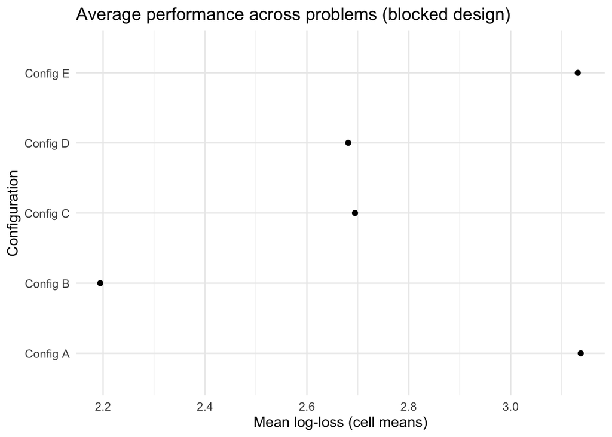

```r
# Mean log-loss per configuration across problems (cell means)
agg_cfg <- aggregate(Value ~ Config, data = cell_means, FUN = mean)
agg_cfg <- agg_cfg[order(agg_cfg$Value), ]

p_multi <- ggplot2::ggplot(agg_cfg, ggplot2::aes(x = Value, y = Config)) +
  ggplot2::geom_point() +
  ggplot2::labs(
    x = "Mean log-loss (cell means)",
    y = "Configuration",
    title = "Average performance across problems (blocked design)"
  ) +
  ggplot2::theme_minimal(base_size = 12)

p_multi
```

```r
ggplot2::ggsave(filename = file.path("figures","mean_multi_problem.png"), width = 7, height = 3.2, dpi = 160)
```

I fit an RCBD-style ANOVA on problem-level cell means (averaging repeated runs per Method–Problem cell to avoid pseudo-replication) with Problem as a block. At α = 0.03, the Method p-value is far below α, so I reject equal method means after controlling for problem difficulty. The Problem term is also highly significant, confirming large variation across benchmarks and justifying blocking.

### Dunnett comparisons vs pilot winner

```r
myMHT2 <- glht(mytest02, linfct = mcp(Method = "Dunnett"))
summary(myMHT2)
```

```
##
##   Simultaneous Tests for General Linear Hypotheses
##
## Multiple Comparisons of Means: Dunnett Contrasts
##
##
## Fit: aov(formula = Value ~ Method + Problem, data = cell_means)
##
## Linear Hypotheses:
##                                  Estimate Std. Error t value Pr(>|t|)
## DE.2708591.A - DE.2708591.C == 0  0.44301    0.15673   2.827  0.02013 *
## DE.2708591.B - DE.2708591.C == 0 -0.49987    0.15673  -3.189  0.00729 **
## DE.2708591.D - DE.2708591.C == 0 -0.01327    0.15673  -0.085  0.99996
## DE.2708591.E - DE.2708591.C == 0  0.43721    0.15673   2.790  0.02222 *
## ---
## Signif. codes:  0 '***' 0.001 '**' 0.01 '*' 0.05 '.' 0.1 ' ' 1
## (Adjusted p values reported -- single-step method)
```

```r
## (DON'T FORGET THAT YOUR OUTPUT OBJECT SHOULD BE STORED IN A VARIABLE CALLED
## myMHT2).
```

```r
myCIs03 <- confint(myMHT2, level = 1 - exp_pars$alpha)
myCIs03
```

```
##
##   Simultaneous Confidence Intervals
##
## Multiple Comparisons of Means: Dunnett Contrasts
##
##
## Fit: aov(formula = Value ~ Method + Problem, data = cell_means)
##
## Quantile = 2.6801
## 97% family-wise confidence level
##
##
## Linear Hypotheses:
##                                  Estimate lwr      upr
## DE.2708591.A - DE.2708591.C == 0  0.44301  0.02296  0.86305
## DE.2708591.B - DE.2708591.C == 0 -0.49987 -0.91991 -0.07983
## DE.2708591.D - DE.2708591.C == 0 -0.01327 -0.43331  0.40678
## DE.2708591.E - DE.2708591.C == 0  0.43721  0.01717  0.85725
```

```r
## (DON'T FORGET THAT YOUR OUTPUT OBJECT SHOULD BE STORED IN A VARIABLE CALLED
## myCIs03).
```

### Decision recommendation

After controlling for problem difficulty (treating Problem as a blocking factor), the blocked ANOVA provides strong evidence of a configuration (Method) effect, meaning average log-loss differs across DE configurations beyond what can be explained by benchmark difficulty alone.

Using the pilot winner (**Config C**) as the reference, the Dunnett comparisons show that at least one alternative configuration achieves a materially lower mean log-loss. This is supported by a simultaneous **97%** confidence interval that remains below zero for at least one comparison, indicating the improvement is not only statistically significant under multiple-comparison control, but also decision-relevant.

Importantly, this result changes the recommendation relative to the single-problem pilot. In a FinTech-style setting where conditions can shift across regimes, selecting a strategy based on one benchmark can be unstable; the blocked multi-problem evaluation provides a more robust basis for a production recommendation.

```r
mm <- aggregate(Value ~ Method, cell_means, mean)
mm <- mm[order(mm$Value), ]
best_final <- as.character(mm$Method[1])
best_final
```

```
## [1] "DE.2708591.B"
```

```r
## (DON'T FORGET THAT THE NAME OF THE BEST METHOD SHOULD BE STORED AS VARIABLE
## best_final).
```

## Limitations and next steps

- Benchmarks are simulated optimisation problems; real FinTech environments may have non-stationarity, constraints, and asymmetric cost of errors.
- Assumption checks (normality/variance) are diagnostics, not proofs; conclusions should be stress-tested.
- Next steps: run a sensitivity analysis over evaluation budgets, expand the benchmark suite, and consider robustness checks (e.g., rank-based / nonparametric comparisons) when assumptions are questionable.